# Ford Gobike Data Exploration

In this document I will explore **Ford gobike dataset**.  
This data set includes information about individual rides made in a bike-sharing system covering the greater San Francisco Bay area.

## Univariate Exploration

**What is the distribution of users according to their ages?**

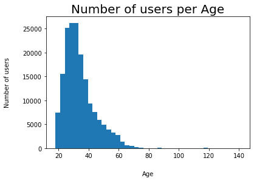

> Most of the users fall between 20 and 40 years, and the closer to the age of 30, the more users

**What is the distribution of users according to their genders?**

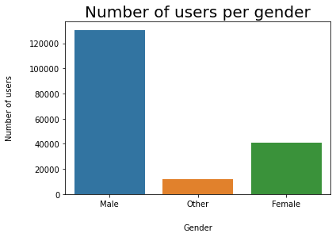

> From the graph, we notice that the number of male users is more than twice as high as females. We also note that there are quite a few whose gender has not been identified

**What is the distribution of users according to week days?**

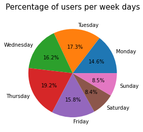

> Thursday has the highest number of users, while Saturday has the lowest

## Bivariate Exploration

**What is the number of users per week days according to their types?**

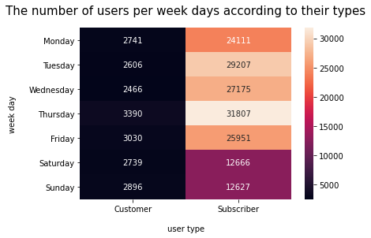

Subscribers are the largest number, and both user types increase in number on Thursday.

**What is the average trip duration per user gender?**

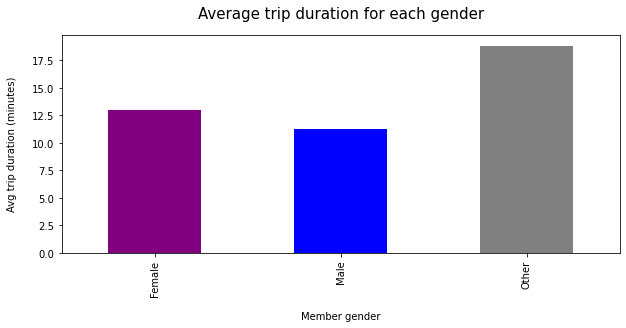

> Regardless of the "other" type, female are the ones who take the longest trips

### Multivariate Exploration

**What is the average trip duration for each user type in week days?**

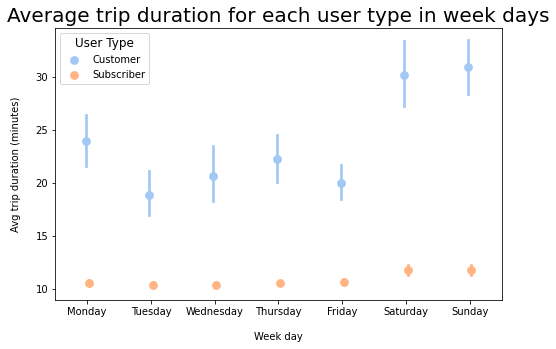

From the graph, we can notice that the weekend (Saturday and Sunday) have the longest average trip duration in both user types. and also the non-subscriber users have the longest trip.

**What is distribution of users over the hours of the day according to their genders and types ?**

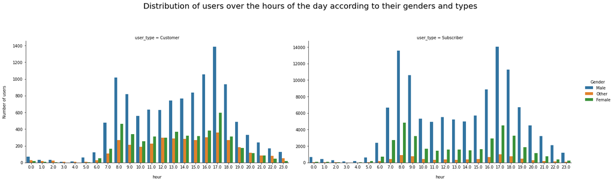